# GastanGO

Sistema de Gestión de Gastos Personales (PERN + Mobile)

Autores/as

Joel Stalin Tapia Pinta

Freddy Alexander Matailo Mora

Fecha de publicación

6 de febrero de 2026

# Resumen Ejecutivo

**NotaSobre el Proyecto**

**GastanGO** es un ecosistema digital diseñado para la salud financiera. Combina la robustez de un backend empresarial con la flexibilidad de una experiencia móvil nativa.

GastanGO es un sistema multiplataforma orientado a la gestión y control de gastos, desarrollado bajo el stack **PERN (PostgreSQL, Express, React y Node.js)** e integrado con una **aplicación móvil cross-platform** construida con **Expo (React Native)**.

El proyecto busca ofrecer una solución accesible, escalable y segura para el registro, visualización y análisis de gastos personales.

# 1 Introducción

En la actualidad, la gestión eficiente de los recursos económicos personales se ha convertido en una necesidad fundamental. GastanGO surge como una propuesta tecnológica que integra tecnologías web modernas y desarrollo móvil multiplataforma.

Este documento presenta la **documentación técnica, arquitectónica y el manual de usuario**, describiendo su funcionamiento interno y guías de uso.

# 2 Objetivos

**🎯 Objetivo General**

Desarrollar un sistema multiplataforma para la gestión de gastos personales utilizando el stack **PERN** y una aplicación móvil basada en **Expo**.

**🚀 Objetivos Específicos**

- **Arquitectura:** Implementar un modelo cliente-servidor desacoplado y escalable.
- **Persistencia:** Diseñar e integrar una base de datos relacional robusta en PostgreSQL.
- **Movilidad:** Desarrollar una aplicación móvil nativa funcional para Android e iOS.
- **UX/UI:** Garantizar una experiencia de usuario intuitiva mediante interfaces modernas.

# 3 Alcance del Proyecto

| Incluye ✅ | No Incluye ❌ |
| --- | --- |
| Registro y autenticación (JWT) | Integración bancaria en tiempo real |
| Gestión CRUD de gastos | Pagos directos desde la app |
| Visualización Web y Móvil | Inteligencia Artificial (Fase 2) |
| Sincronización vía API REST |  |

# 4 Arquitectura del Sistema

El sistema sigue un patrón de diseño **cliente-servidor** desacoplado. A continuación se detallan los niveles basados en el **Modelo C4**.

## 4.1 Diagramas C4 (Structurizr)

Para entender la arquitectura, utilizamos el modelo C4. Los siguientes diagramas están en formato vectorial (SVG) para una visualización de alta calidad sin pérdida de resolución.

**Tip📌 Guía: Cómo interpretar los diagramas Structurizr**

**Niveles de Zoom:**

1. **C1 - Context:** Visión general del negocio y actores externos.
2. **C2 - Container:** Tecnología (Web, API, Mobile, DB).
3. **C3 - Component:** Estructura interna (Controladores, Servicios).
4. **C4 - Despliegue:** Infraestructura y configuración de despliegue.

### 4.1.1 Galería de Arquitectura

[figure not shown]

Vista de Contexto (C1)

[figure not shown]

Vista de Contenedores (C2)

[figure not shown]

Componentes Backend (C3)

[figure not shown]

Componentes Frontend (C3)

[figure not shown]

Infraestructura de Despliegue

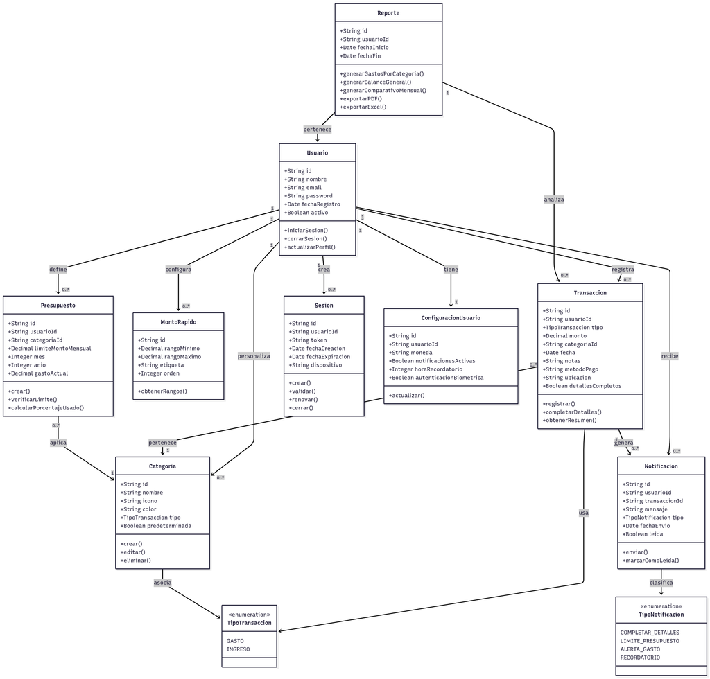

Diagrama de codigo

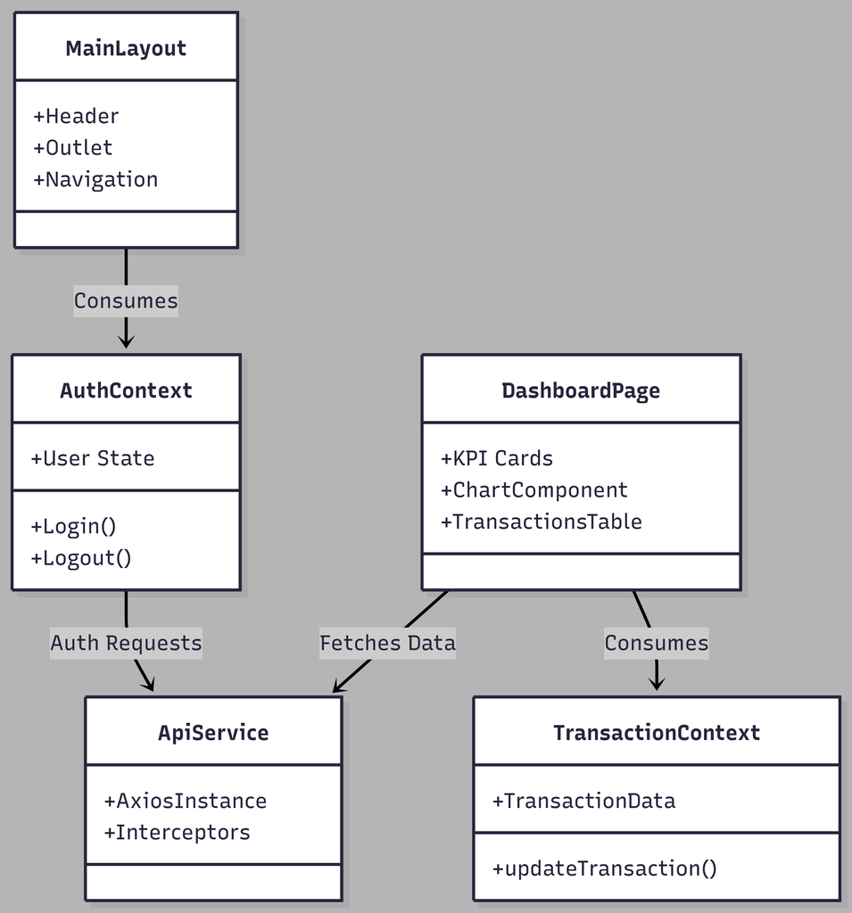

Diagrama de codigo Frontend

Explorar diagramas Ver Keys

## 4.2 Llaves de Arquitectura (Leyendas)

Los diagramas de arquitectura utilizan una **notación estandarizada** basada en el modelo C4. A continuación se presentan las llaves o leyendas que explican los elementos visuales empleados en cada nivel arquitectónico:

**Tip🔑 Importancia de las Llaves**

Las llaves proporcionan una guía visual para interpretar correctamente cada diagrama, identificando los tipos de componentes, las relaciones entre ellos y las tecnologías empleadas.

### 4.2.1 Leyendas por Nivel de Arquitectura

[figure not shown]

Leyenda - Contexto

[figure not shown]

Leyenda - Contenedores

[figure not shown]

Leyenda - Login

[figure not shown]

Leyenda - Backend

[figure not shown]

Leyenda - Frontend

[figure not shown]

Leyenda - Despliegue

**Importante📐 Convenciones de Diseño**

- **Rectángulos azules:** Sistemas externos (usuarios, servicios de terceros)
- **Rectángulos verdes:** Contenedores de la aplicación (Web, API, Mobile, DB)
- **Componentes internos:** Capas de controladores, servicios y modelos
- **Flechas continuas:** Comunicación sincrónica (HTTP/REST)
- **Flechas punteadas:** Dependencias o relaciones opcionales

## 4.3 Stack Tecnológico

El sistema sigue una arquitectura **cliente-servidor** desacoplada:

- **Frontend Web:** React (Vite + Tailwind CSS)
- **Backend:** Node.js + Express (API REST)
- **Base de Datos:** PostgreSQL 16
- **Mobile App:** Expo (React Native)

# 5 Diseño Móvil (Cross-Platform)

La aplicación móvil fue desarrollada siguiendo el paradigma **cross-platform**, permitiendo su ejecución tanto en Android como en iOS a partir de una única base de código.

**Ventajas Clave:**

1. Reducción de costos de desarrollo.
2. Mantenimiento unificado.
3. Consistencia en la experiencia de usuario.

## 5.1 Capturas de Pantalla de la Aplicación Móvil

A continuación se presentan las principales pantallas de la aplicación móvil **GastanGO**, mostrando la interfaz de usuario y las funcionalidades implementadas:

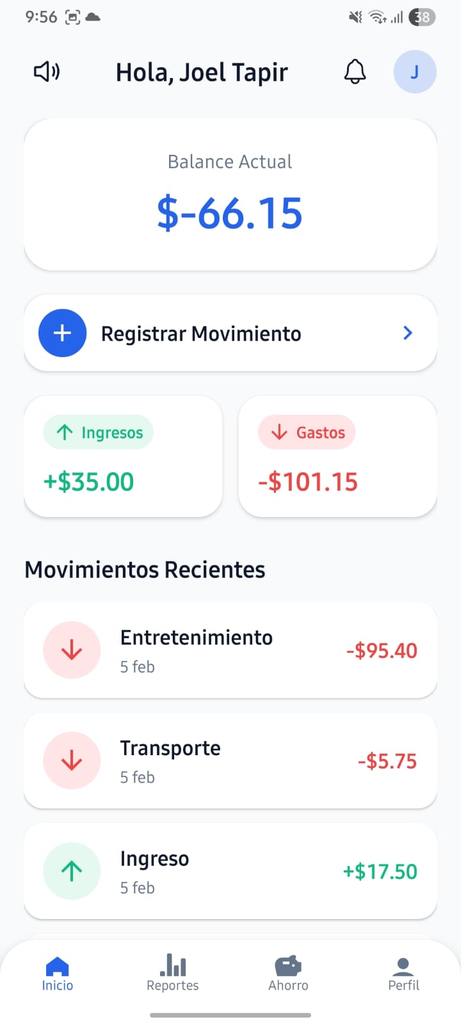

Pantalla de Inicio

[figure not shown]

Registro de Usuario

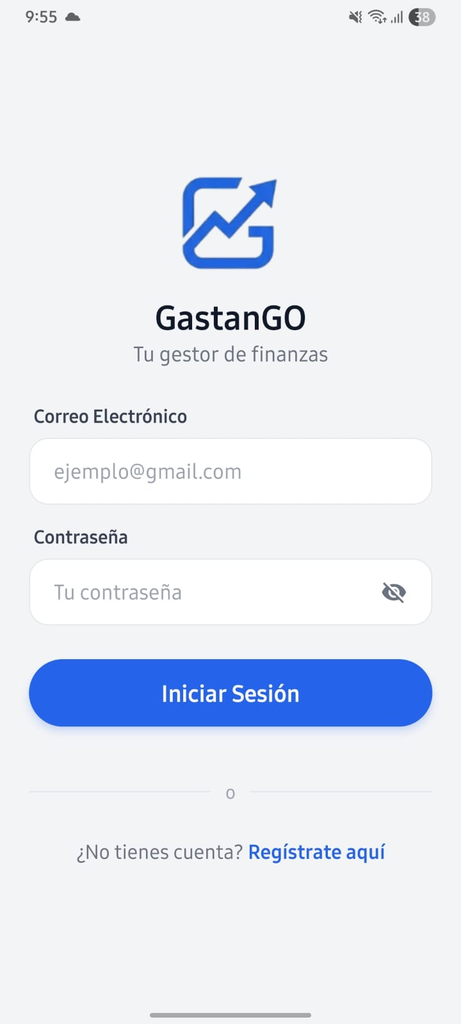

Inicio de Sesión

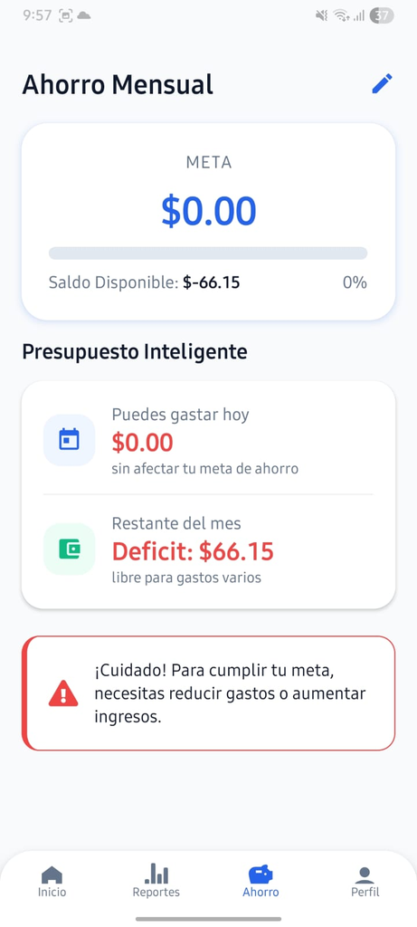

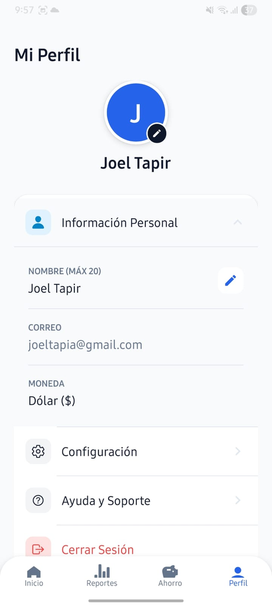

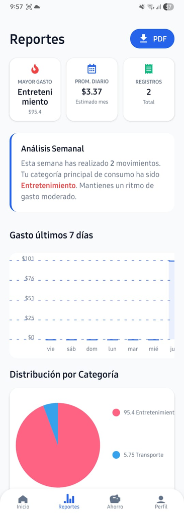

**Nota📱 Experiencia de Usuario**

La aplicación mantiene una interfaz consistente y moderna, siguiendo los principios de **Material Design** para Android y **Human Interface Guidelines** para iOS, garantizando una experiencia nativa en ambas plataformas.

# 6 Seguridad e Implementación

El sistema implementa mecanismos de defensa en profundidad:

- 🔐 **Autenticación:** JWT (JSON Web Tokens).
- 🛡️ **Validación de Datos:** Uso de middlewares en Express con librerías de validación (Zod/Express-validator).
- 🔒 **Cifrado:** Hasheo de credenciales en base de datos.
- 🚦 **Rutas Protegidas:** Guardias de navegación en Frontend y Mobile.
- 🌐 **Cross-Platform:** Código unificado mediante el SDK de Expo.

# 7 Documentación Multimedia

## 7.1 Demostración Funcional

A continuación, se presenta una demostración funcional del sistema en operación:

[video not shown]

# 8 Manual de Usuario

## 8.1 Instalación

### 8.1.1 Requisitos

- Dispositivo Android (6.0+) o iOS (13+).
- Conexión a Internet activa.

### 8.1.2 Descarga de la Aplicación

Puedes acceder a la última compilación de desarrollo a través de Expo:

🔗 **[Descargar GastanGO Mobile (Expo Build)](https://expo.dev/accounts/jxel117/projects/gastango-mobile/builds/7f8a8928-4c10-41a9-baf2-91a5bea4c258)**

## 8.2 Uso Básico

1. **Registro:** Crea una cuenta con tu correo electrónico.
2. **Dashboard:** Visualiza tu saldo actual y resumen de transacciones.
3. **Nueva Transacción:** Pulsa el botón `+` para agregar un gasto o ingreso.
4. **Historial:** Revisa tus movimientos pasados en la pestaña de reportes.

# 9 Repositorio y Código Fuente

El desarrollo es de código abierto y está disponible para revisión y contribución.

https://github.com/Jxel117/GastanGO

[Ver Repositorio en GitHub](https://github.com/Jxel117/GastanGO)

# 10 Conclusiones

GastanGO demuestra la viabilidad de integrar tecnologías web modernas con desarrollo móvil multiplataforma, ofreciendo una solución práctica y eficiente para la gestión de finanzas personales.

El proyecto evidencia la aplicación de buenas prácticas en arquitectura de software, seguridad y experiencia de usuario.

**Desarrollado por:**

- **Joel Stalin Tapia Pinta** (Jxel117)
- **Freddy Alexander Matailo Mora** (FreddyAlx1998Mora12)

https://github.com/Jxel117/

https://github.com/FreddyAlx1998Mora12

*Universidad Nacional de Loja - Ingeniería en Ciencias de la Computación - 2026*